# Purpose Financial Data Challenge: Predicting Customer Default

## Testing Data and Submission file

The final steps are to feed the testing data into our chosen model and create a submission file. wWe will also compare the predictions from the two models.

```python
test_df = pd.read_csv(data_path + 'test.csv')
```

```python
test_df = data_preprocess(test_df)
ids = test_df['id'].tolist()
```

```
13 rows with negative dependants, setting equal to 0 (min -1)
```

From the data preprocessing summary we do not have any nulls or duplicates and we did not have the age issue, but again found a small number of negative dependants.

```python
test_df_lr = test_df[lr_base_dict['X_train'].columns]

test_df_xgb = test_df[xgb_dict['X_train'].columns]
```

```python
# make predictions for  test data using XGBoost
y_pred_xgb = model_HT.predict(test_df_xgb)
y_proba_xgb = model_HT.predict_proba(test_df_xgb)
```

```python
# make predictions for (scaled) test data using Logistic Regression
scaler = preprocessing.StandardScaler().fit(lr_base_dict['X_train'])
test_df_lr_scaled = pd.DataFrame(scaler.transform(test_df_lr), columns=test_df_lr.columns)
y_pred_lr = lr_base_model.predict(test_df_lr_scaled)
y_proba_lr = lr_base_model.predict_proba(test_df_lr_scaled)
```

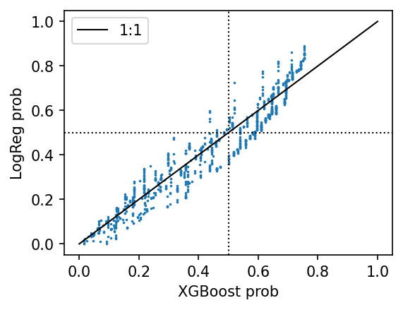

```python
plt.figure(figsize=(4, 3), dpi=150)
plt.plot([0,1], [0,1], lw=1, color='k', label='1:1')
plt.scatter(y_proba_xgb[:, 1], y_proba_lr[:, 1], s=0.5)



plt.axvline(0.5, lw=1, color='k', ls=':')
plt.axhline(0.5, lw=1, color='k', ls=':')

plt.ylabel('LogReg prob')
plt.xlabel('XGBoost prob')
plt.legend()
```

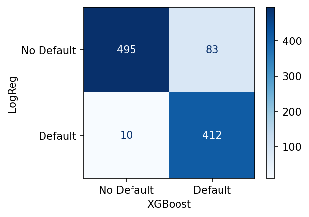

```python
plt.figure(figsize=(4,3), dpi=150)
ax = plt.gca()

log_cm = confusion_matrix(y_pred_lr, y_pred_xgb)

# Create display of confusion matrix
log_disp = ConfusionMatrixDisplay(confusion_matrix=log_cm, display_labels=['No Default', 'Default'])
log_disp.plot(cmap='Blues',ax=ax)


ax.set_ylabel('LogReg')
ax.set_xlabel('XGBoost')
```

The XGBoost model is more likely to assign a "default" label than the Logistic regression model. This is expected as the XGBoost model had hyperparameters tuned to maximize recall. Given the greater negative impacts of a False Negative than a False Positive, this is motivation for using the XGBoost model.

```python
submission_df = pd.DataFrame({'id':ids, 'prediction':y_proba_xgb[:,1], 'outcome':y_pred_xgb})
```

```python
submission_df.to_csv(data_path + 'submission.csv', index=False)
```

## Conclusions

**Results**

We were given the task of developing a model for predicting whether or not a consumer will default on their loan. We developed two primary models: a logistic regression based on only the monthly income and average score of the consumer, and an CGBoost based classifier that uses these and other parameters.

We showed that in both models the monthly income and score average were the most important features to the model whether or not other features were included.

To handle class imbalances we used class weighting in both models, with a fixed class weight determined by the majority minority class ratio.

Our primary metric of interest was the recall. The logistic regression model yielded a recall of ~72% while the XGBoost classifier yielded a recall of ~78%. Despite the greater simplicity and explainability of the logistic regression model, we determine that the performance improvements of the XGboost model are more important.

Thus our recommendation is to employ the hyperparameter tuned XGboost classifier model.

Below we outline some potential approaches to an expanded analysis and additional data that could possibly add to the analysis.

**Additional analysis:**

- Using a better evaluation metric would work best. I would ideally try a $F_{\beta}$ metric where $\beta$ is determined by e.g. average profit made on a loan and average loss for each default. This I believe would be the biggest improvement to the analysis and would better connect the models with business needs.
- Analysis of the incorrect values (i.e. when the models are wrong, are there any patterns in the data of the incorrect predictions?).
- Partial dependence plots for feature interpretation
- Optimization of class weights; we explored how this could be done, but did not dive into a robust implementation.
- Threshold-moving. Based on PR curves there may be room to improve recall while minimally affecting other metrics.
- Improved feature engineering
- Optimizing Feature Selection

**Additional data that could be useful:**

- Payment history: e.g. how many late payments over life of the loan (constrast with only knowing 90 day delinquency)
- Current loan Rates
- Spending data: we have debt info, but not spending habits
- Historical data on payments, spending, debt etc that could provide trend information
- Geographic data